# Exploratory Data Analysis Report

2022-11-20

## Exploratory Data analysis (EDA)

Analyzing the data sets to summarize their main characteristics of variables, often with visual graphs, without using a statistical model.

### 1. Overview of the data

Understanding the dimensions of the dataset, variable names, overall missing summary and data types of each variables

```r
# Overview of the data
ExpData(data=data,type=1)
# Structure of the data
ExpData(data=data,type=2)
```

**Overview of the data**

| Descriptions | Value |
| --- | --- |
| Sample size (nrow) | 37912 |
| No. of variables (ncol) | 67 |
| No. of numeric/interger variables | 65 |
| No. of factor variables | 0 |
| No. of text variables | 2 |
| No. of logical variables | 0 |
| No. of identifier variables | 1 |
| No. of date variables | 0 |
| No. of zero variance variables (uniform) | 1 |
| %. of variables having complete cases | 98.51% (66) |

[output cut: 3 more lines]

**Structure of the data**

| Index | Variable_Name | Variable_Type | Sample_n | Missing_Count | Per_of_Missing | No_of_distinct_values |
| --- | --- | --- | --- | --- | --- | --- |
| 1 | client_id | integer | 37912 | 0 | 0.000 | 37912 |
| 2 | DaysSinceTransaction | integer | 37912 | 0 | 0.000 | 518 |
| 3 | TrxCount__6 | integer | 37912 | 0 | 0.000 | 174 |
| 4 | TrxCount__12 | integer | 37912 | 0 | 0.000 | 269 |
| 5 | TrxCount__3 | integer | 37912 | 0 | 0.000 | 117 |
| 6 | TrxCount | integer | 37912 | 0 | 0.000 | 318 |
| 7 | TotalDepositAmount__6 | numeric | 37912 | 0 | 0.000 | 13048 |
| 8 | TotalDepositAmount__12 | numeric | 37912 | 0 | 0.000 | 19895 |
| 9 | TotalDepositAmount__3 | numeric | 37912 | 0 | 0.000 | 8775 |
| 10 | TotalDepositAmount | numeric | 37912 | 0 | 0.000 | 25211 |

[output cut: 57 more lines]

**Target variable**

Summary of categorical dependent variable

```
##   Churn Frequency Descriptions
## 1    No     29472        Churn
## 2   Yes      8440        Churn
```

### 2. Summary of numerical variables

Summary of all numerical variables

Summary statistics when dependent variable is categorical **Churn**. Summary statistics will be splitted into category level

```r
ExpNumStat(data,by="GA",gp=Target,Qnt=seq(0,1,0.1),MesofShape=2,Outlier=TRUE,round=2)
```

| Vname | Group | TN | nNeg | nZero | nPos | NegInf | PosInf | NA_Value | Per_of_Missing | sum | min | max | mean | median | SD | CV | IQR | Skewness | Kurtosis | 0% | 10% | 20% | 30% | 40% | 50% | 60% | 70% | 80% | 90% | … |
| --- | --- | --- | --- | --- | --- | --- | --- | --- | --- | --- | --- | --- | --- | --- | --- | --- | --- | --- | --- | --- | --- | --- | --- | --- | --- | --- | --- | --- | --- | --- |
| age | Churn:All | 37912 | 0 | 0 | 40 | 0 | 0 | 37872 | 99.89 | 1.311000e+03 | 21.00 | 6.800000e+01 | 32.77 | 31.00 | 8.59 | 0.26 | 5.75 | 2.09 | 5.75 | 21.00 | 25.00 | 26.80 | 29.00 | 30.00 | 31.00 | 32.40 | 34.00 | 35.20 | 43.10 | … |
| age | Churn:Yes | 8440 | 0 | 0 | 11 | 0 | 0 | 8429 | 99.87 | 3.240000e+02 | 26.00 | 3.500000e+01 | 29.45 | 30.00 | 2.88 | 0.10 | 3.50 | 0.47 | -0.64 | 26.00 | 26.00 | 27.00 | 27.00 | 29.00 | 30.00 | 30.00 | 30.00 | 31.00 | 33.00 | … |
| age | Churn:No | 29472 | 0 | 0 | 29 | 0 | 0 | 29443 | 99.90 | 9.870000e+02 | 21.00 | 6.800000e+01 | 34.03 | 32.00 | 9.69 | 0.28 | 7.00 | 1.69 | 3.58 | 21.00 | 24.80 | 27.80 | 29.40 | 31.00 | 32.00 | 33.80 | 34.60 | 38.80 | 44.20 | … |
| avDeposit | Churn:All | 37912 | 0 | 0 | 37912 | 0 | 0 | 0 | 0.00 | 3.411088e+07 | 0.27 | 5.000000e+04 | 899.74 | 333.40 | 1658.85 | 1.84 | 934.36 | 5.64 | 61.12 | 0.27 | 31.98 | 72.31 | 130.15 | 211.00 | 333.40 | 524.11 | 830.33 | 1292.51 | 2181.78 | … |
| avDeposit | Churn:Yes | 8440 | 0 | 0 | 8440 | 0 | 0 | 0 | 0.00 | 4.941124e+06 | 0.67 | 5.000000e+04 | 585.44 | 222.24 | 1295.16 | 2.21 | 556.23 | 12.41 | 321.24 | 0.67 | 31.00 | 57.45 | 98.47 | 150.28 | 222.24 | 329.00 | 497.95 | 799.48 | 1371.17 | … |
| avDeposit | Churn:No | 29472 | 0 | 0 | 29472 | 0 | 0 | 0 | 0.00 | 2.916975e+07 | 0.27 | 3.333333e+04 | 989.74 | 387.18 | 1738.71 | 1.76 | 1060.55 | 4.76 | 36.79 | 0.27 | 32.48 | 79.09 | 145.40 | 238.53 | 387.18 | 605.63 | 951.83 | 1430.33 | 2391.17 | … |
| avDeposit__12 | Churn:All | 37912 | 0 | 9003 | 28909 | 0 | 0 | 0 | 0.00 | 3.342346e+07 | 0.00 | 5.818438e+04 | 881.61 | 194.70 | 1954.69 | 2.22 | 930.33 | 6.57 | 84.43 | 0.00 | 0.00 | 0.00 | 21.65 | 90.00 | 194.70 | 373.53 | 685.08 | 1245.19 | 2309.33 | … |
| avDeposit__12 | Churn:Yes | 8440 | 0 | 8440 | 0 | 0 | 0 | 0 | 0.00 | 0.000000e+00 | 0.00 | 0.000000e+00 | 0.00 | 0.00 | 0.00 | NaN | 0.00 | NaN | NaN | 0.00 | 0.00 | 0.00 | 0.00 | 0.00 | 0.00 | 0.00 | 0.00 | 0.00 | 0.00 | … |
| avDeposit__12 | Churn:No | 29472 | 0 | 563 | 28909 | 0 | 0 | 0 | 0.00 | 3.342346e+07 | 0.00 | 5.818438e+04 | 1134.08 | 400.14 | 2151.44 | 1.90 | 1186.32 | 6.01 | 70.72 | 0.00 | 21.65 | 69.92 | 140.20 | 240.38 | 400.14 | 639.23 | 1021.76 | 1614.27 | 2805.50 | … |
| avDeposit__3 | Churn:All | 37912 | 0 | 25271 | 12641 | 0 | 0 | 0 | 0.00 | 2.175983e+07 | 0.00 | 5.818438e+04 | 573.96 | 0.00 | 1831.68 | 3.19 | 213.78 | 8.11 | 123.19 | 0.00 | 0.00 | 0.00 | 0.00 | 0.00 | 0.00 | 0.00 | 50.00 | 500.00 | 1687.35 | … |

[output cut: 176 more lines]

### 3. Distributions of Numerical variables

- Box plots for all numerical variables vs categorical dependent variable - Bivariate comparision only with categories
  - Quantile-quantile plot(Univariate)
  - Density plot (Univariate)
  - Box plot (Univariate and Bivariate)
  - Scatter plot (Bivariate)

#### Quantile-quantile plot for Numerical variables - Univariate

Quantile-quantile plot for all Numerical variables

```r
ExpOutQQ(data,nlim=4,fname=NULL,Page=c(2,2),sample=sn)
```

```
## $`0`
```

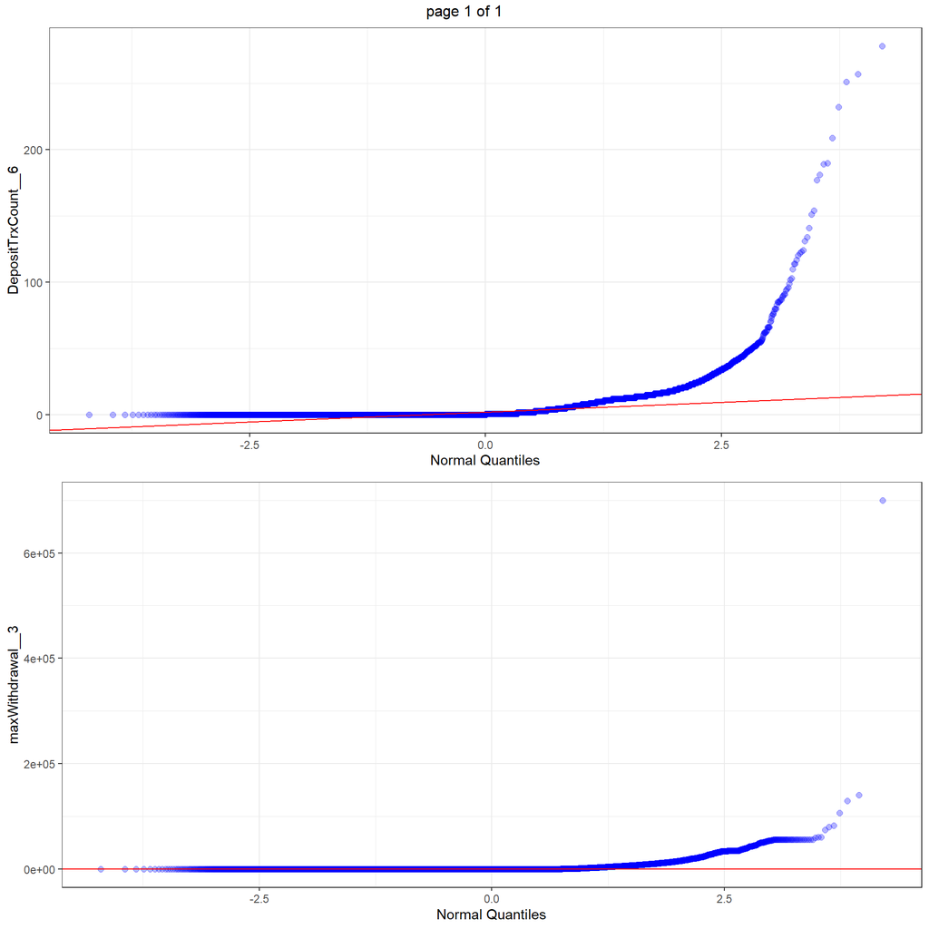

#### Density plots for Numerical variables - Univariate

Density plot for all Numerical variables

```
## $`0`
```

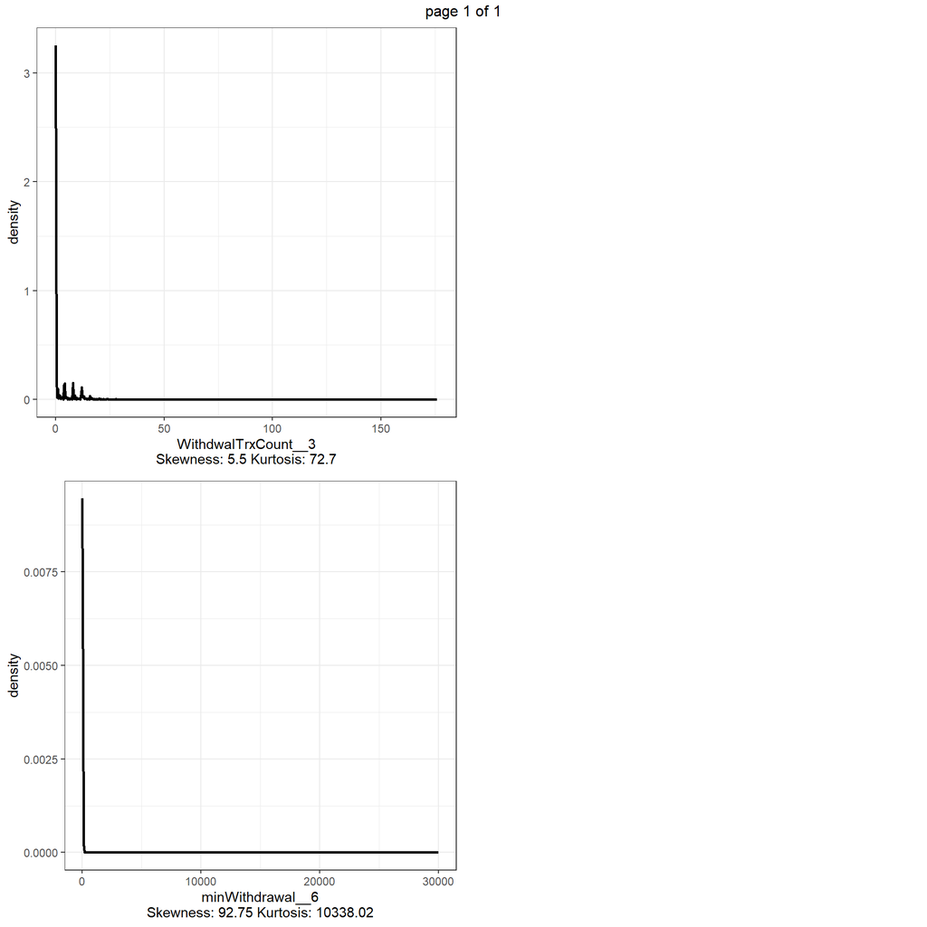

```r
ExpNumViz(data,target=NULL,type=1,Page=c(2,2),theme=theme,sample=sn)
```

#### Scatter plot for all numeric features - Bivariate analysis

```
## $`0`
```

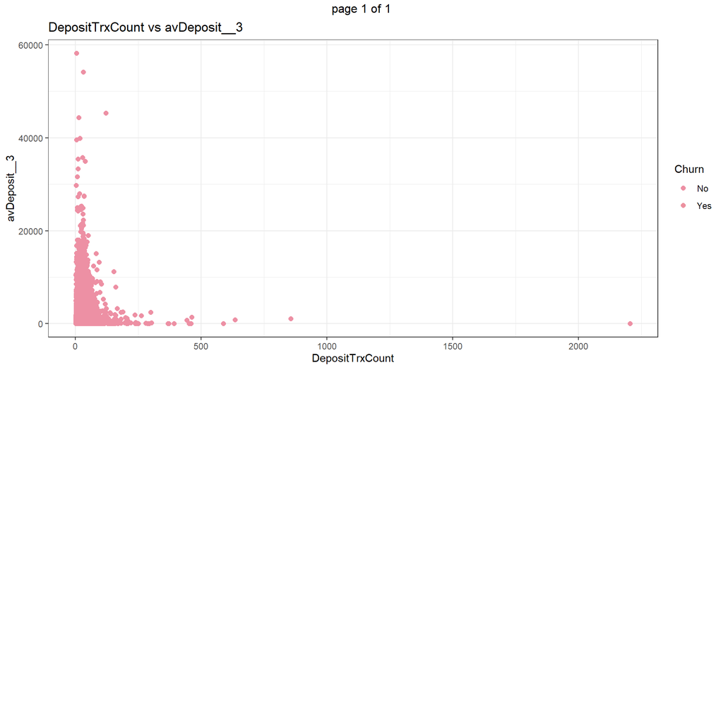

```r
ExpNumViz(data,target=Target,Page=c(2,1),theme=theme,sample=sn,scatter=TRUE)
```

#### Box plots for all numeric features vs categorical dependent variable - Bivariate comparision only with categories

Boxplot for all the numeric attributes by each category of **Churn**

```
## $`0`
```

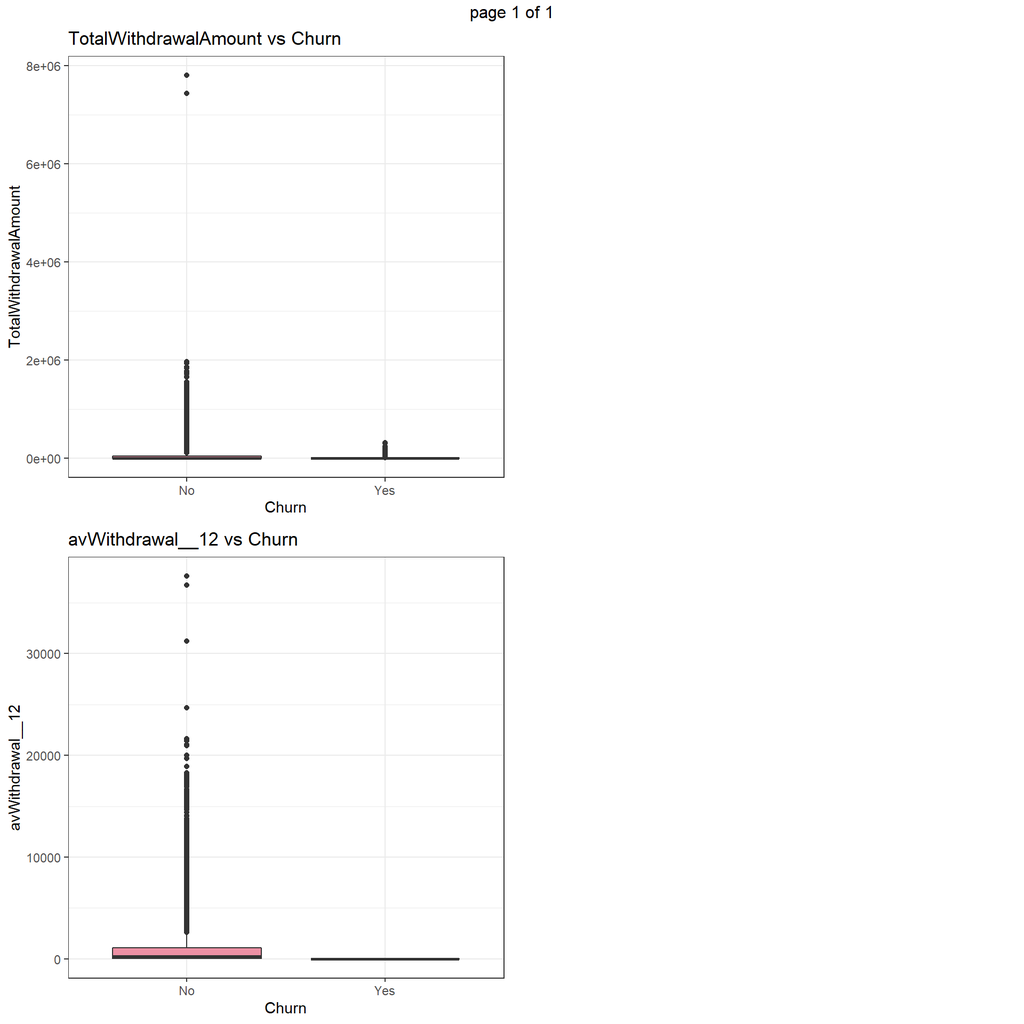

```r
ExpNumViz(data,target=Target,type=2,theme=theme,Page=c(2,2),sample=sn)
```

### 4. Summary of categorical variables

Summary of categorical variable

**Cross tabulation with target variable**

- Custom tables between all categorical independent variables and traget variable **Churn**

```r
ExpCTable(data,Target=Target,margin=1,clim=10,nlim=5,round=2,bin=NULL,per=F)
```

| VARIABLE | CATEGORY | Churn:No | Churn:Yes | TOTAL |
| --- | --- | --- | --- | --- |
| gender | F | 7278 | 2176 | 9454 |
| gender | M | 22194 | 6264 | 28458 |
| gender | TOTAL | 29472 | 8440 | 37912 |
| HasFixedDeposit | 0 | 28907 | 8429 | 37336 |
| HasFixedDeposit | 1 | 565 | 11 | 576 |
| HasFixedDeposit | TOTAL | 29472 | 8440 | 37912 |

**Information Value**

```r
ExpCatStat(data,Target=Target,Label=label,result = "IV",clim=10,nlim=5,Pclass=Rc)
```

| Variable | Class | Out_1 | Out_0 | TOTAL | Per_1 | Per_0 | Odds | WOE | IV | Ref_1 | Ref_0 | Target |
| --- | --- | --- | --- | --- | --- | --- | --- | --- | --- | --- | --- | --- |
| gender.1 | F | 2176 | 7278 | 9454 | 0.26 | 0.25 | 1.06 | 0.04 | 0.00 | Yes | No | Churn |
| gender.2 | M | 6264 | 22194 | 28458 | 0.74 | 0.75 | 0.94 | -0.01 | 0.00 | Yes | No | Churn |
| HasFixedDeposit.1 | 0 | 8429 | 28907 | 37336 | 1.00 | 0.98 | 14.98 | 0.02 | 0.00 | Yes | No | Churn |
| HasFixedDeposit.2 | 1 | 11 | 565 | 576 | 0.00 | 0.02 | 0.07 | 0.00 | 0.00 | Yes | No | Churn |
| client_id.1 | [11530,21514] | 1215 | 2576 | 3791 | 0.14 | 0.09 | 1.76 | 0.44 | 0.02 | Yes | No | Churn |
| client_id.2 | (21514,28205] | 1085 | 2706 | 3791 | 0.13 | 0.09 | 1.46 | 0.36 | 0.01 | Yes | No | Churn |
| client_id.3 | (28205,34740] | 988 | 2804 | 3792 | 0.12 | 0.10 | 1.26 | 0.18 | 0.00 | Yes | No | Churn |
| client_id.4 | (34740,42875] | 1047 | 2744 | 3791 | 0.12 | 0.09 | 1.38 | 0.29 | 0.01 | Yes | No | Churn |
| client_id.5 | (42875,51450] | 1060 | 2731 | 3791 | 0.13 | 0.09 | 1.41 | 0.36 | 0.01 | Yes | No | Churn |
| client_id.6 | (51450,62268] | 1169 | 2622 | 3791 | 0.14 | 0.09 | 1.65 | 0.44 | 0.02 | Yes | No | Churn |

[output cut: 357 more lines]

**Statistical test**

```r
ExpCatStat(data,Target=Target,Label=label,result = "Stat",clim=10,nlim=5,Pclass=Rc)
```

| Variable | Target | Unique | Chi-squared | p-value | df | IV Value | Cramers V | Degree of Association | Predictive Power |
| --- | --- | --- | --- | --- | --- | --- | --- | --- | --- |
| gender | Churn | 2 | 4.086 | 0.043 | 1 | 0.00 | 0.01 | Very Weak | Not Predictive |
| HasFixedDeposit | Churn | 2 | 138.800 | 0.000 | 1 | 0.00 | 0.06 | Very Weak | Not Predictive |
| client_id | Churn | 10 | 2925.340 | 0.000 | 9 | 0.08 | 0.28 | Moderate | Not Predictive |
| DaysSinceTransaction | Churn | 10 | 33986.475 | 0.000 | 9 | 0.00 | 0.95 | Strong | Not Predictive |
| TrxCount__6 | Churn | 6 | 7541.465 | 0.000 | 5 | 0.40 | 0.45 | Strong | Highly Predictive |
| TrxCount__12 | Churn | 8 | 24404.748 | 0.000 | 7 | 1.97 | 0.80 | Strong | Highly Predictive |
| TrxCount__3 | Churn | 4 | 4148.851 | 0.000 | 3 | 0.16 | 0.33 | Strong | Somewhat Predictive |
| TrxCount | Churn | 10 | 8469.892 | 0.000 | 9 | 0.91 | 0.47 | Strong | Highly Predictive |
| TotalDepositAmount__6 | Churn | 5 | 7215.114 | 0.000 | 4 | 0.36 | 0.44 | Strong | Highly Predictive |
| TotalDepositAmount__12 | Churn | 8 | 24111.175 | 0.000 | 7 | 1.97 | 0.80 | Strong | Highly Predictive |

[output cut: 55 more lines]

**Variable importance based on Information value**

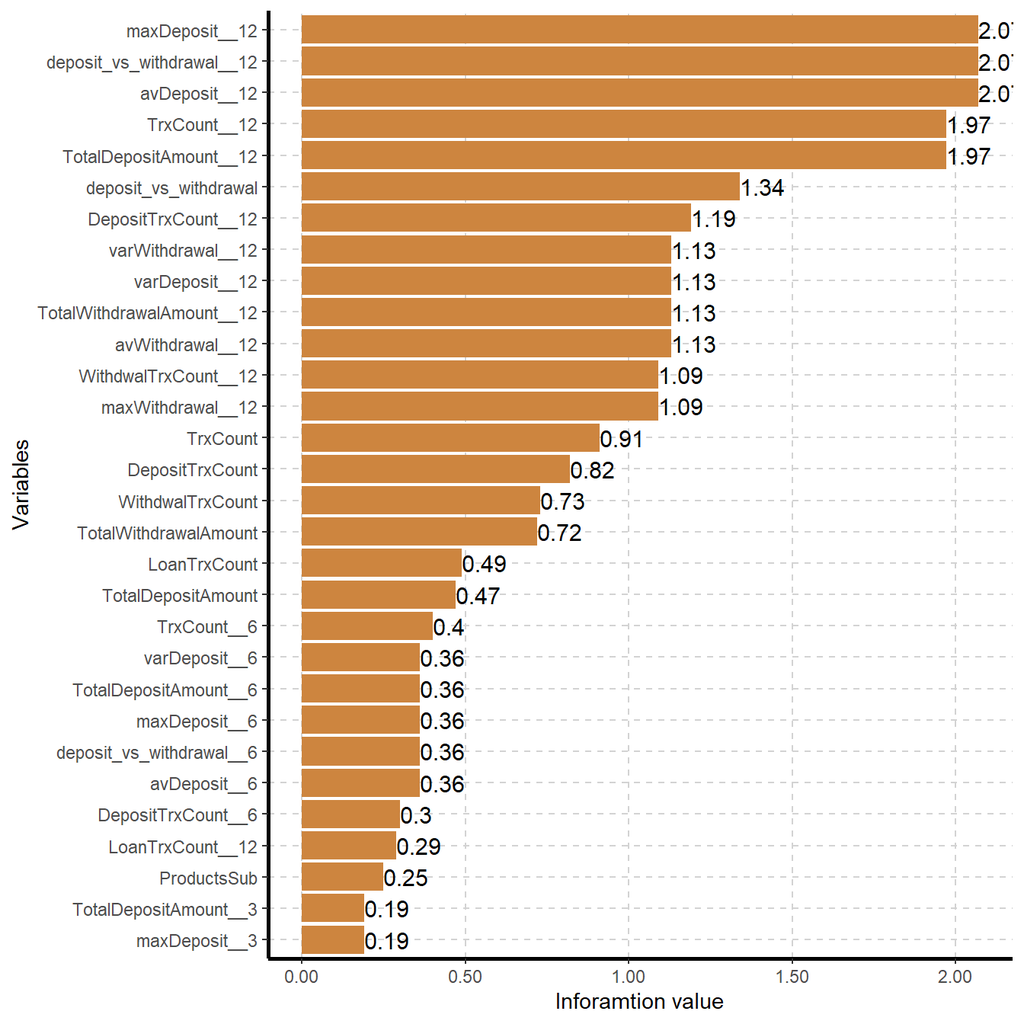

```r
varimp <- ExpCatStat(data,Target=Target,result = "Stat",clim=10,nlim=5,Pclass=Rc,bins=10,plot=TRUE,top=30,Round=2)
```

### 5. Distributions of categorical variables

Graphical representation of all categorical variables

- Bar plot (Univariate)
- Stacked Bar plot (Bivariate)

**Bar plots for all categorical variables**

- Bar plot with vertical or horizontal bars for all categorical variables

```
## $`0`
```

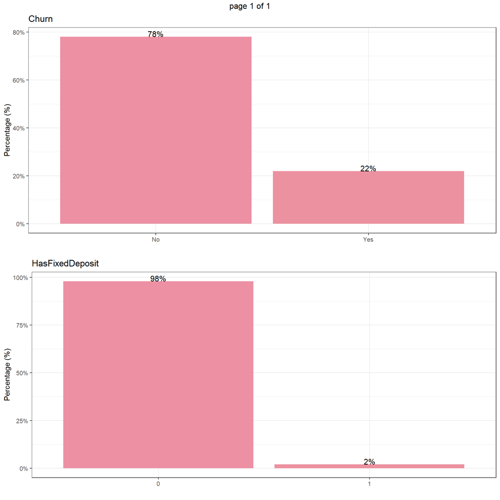

```r
ExpCatViz(data,target=NULL,fname=NULL,clim=10,margin=2,theme=theme,Page = c(2,1),sample=sc)
```

- Stacked bar plot with vertical or horizontal bars for all categorical variables

```
## $`0`
```

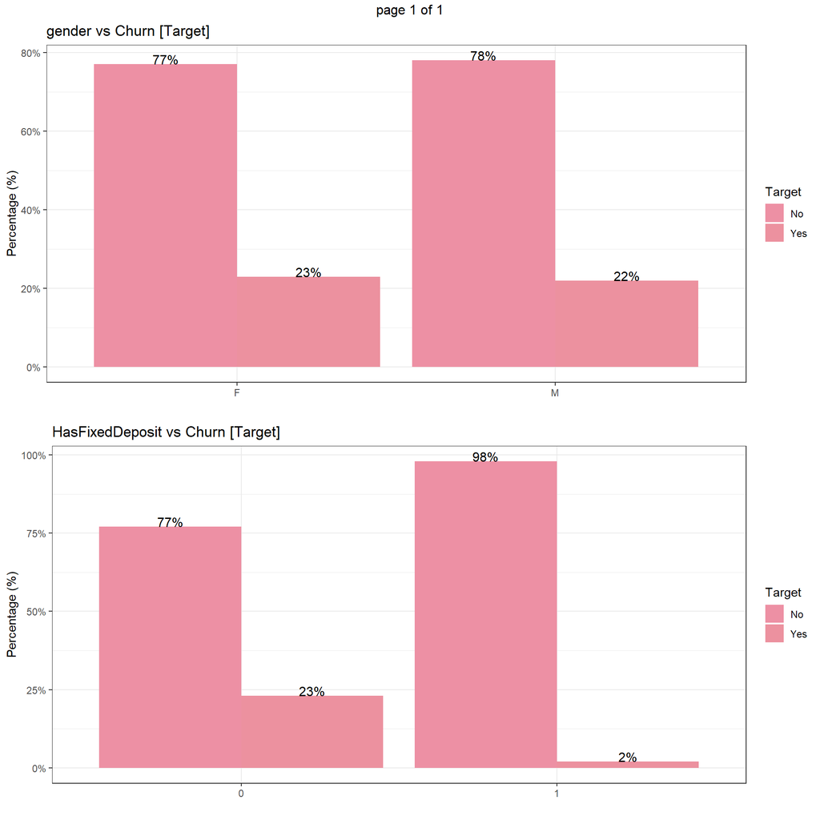

```r
ExpCatViz(data,target=Target,fname=NULL,clim=10,margin=2,theme=theme,Page = c(2,1),sample=sc)
```